# ggplot basics

Ben Bolker

29 April 2016

- newest R graphics framework
- based on Wilkinson’s ‘’Grammar of Graphics’’
- documented in a book (see below) and on a [web site](http://had.co.nz/ggplot2), as well as an active [mailing list](http://groups.google.com/group/ggplot2)
- explicit mapping from variables to ‘’aesthetics’’: x, y, colour, size, shape
- implements *faceting*
- some data summaries etc. built in
- easier to overlay multiple data sets, data summaries, model predictions etc.
- no 3D plots
- rendering can be slow
- `gridExtra`, `directlabels` package may be handy

## ggplot intro

mappings + geoms

### Data

Specified explicitly as part of a `ggplot` call:

```r
library(mlmRev)
head(Oxboys)
```

```
##   Subject     age height Occasion
## 1       1 -1.0000  140.5        1
## 2       1 -0.7479  143.4        2
## 3       1 -0.4630  144.8        3
## 4       1 -0.1643  147.1        4
## 5       1 -0.0027  147.7        5
## 6       1  0.2466  150.2        6
```

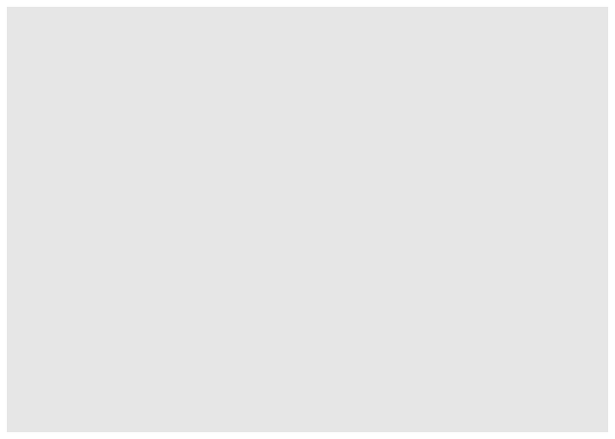

```r
library(ggplot2)
ggplot(Oxboys)
```

But that isn’t quite enough: we need to specify a *mapping* between variables (columns in the data set) and *aesthetics* (elements of the graphical display: x-location, y-location, colour, size, shape …)

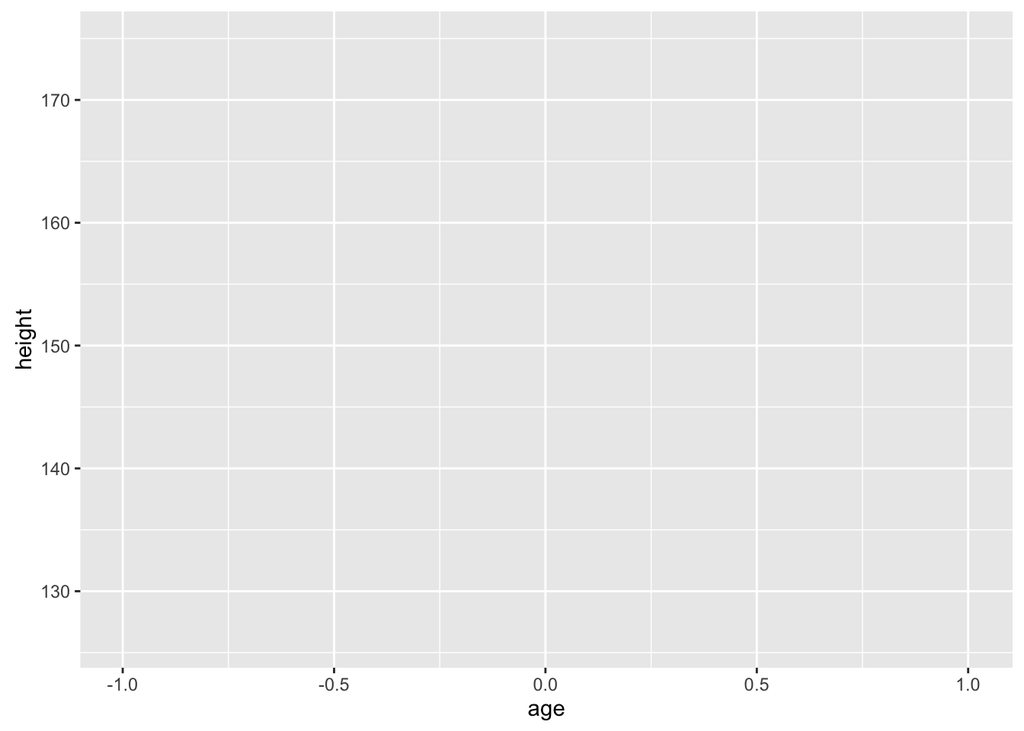

```r
ggplot(Oxboys,aes(x=age,y=height))
```

but (as you can see) that’s still not quite enough. We need to specify some geometric objects (called `geom`s) such as points, lines, etc., that will embody these aesthetics. The weirdest thing about `ggplot` syntax is that these `geom`s get *added* to the existing `ggplot` object that specifies the data and aesthetics; unless you explicitly specify other aesthetics, they are inherited from the initial `ggplot` call.

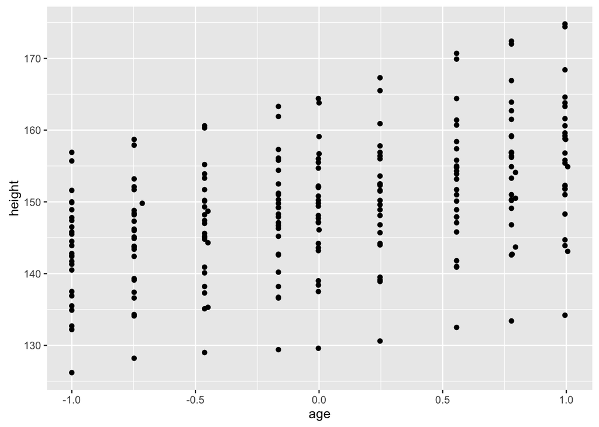

```r
ggplot(Oxboys,aes(x=age,y=height))+geom_point()
```

- many more geoms (lines, bars, etc.)
- summarizers: smooth lines and summaries (`geom_smooth`, `stat_sum`)
- control of scales (e.g. log transforms, colors, etc.)
- faceting (grid and wrap)

See [Karthik’s ggplot intro](https://github.com/karthikram/ggplot-lecture) or [my intro for disease ecologists](http://ms.mcmaster.ca/~bolker/eeid/ecology/ggplot.pdf), among many others.

## Techniques for multilevel data

- faceting (= trellis plots = small multiples) vs grouping (“spaghetti plots”)
- join data within a group by lines (perhaps thin/transparent)
- can colour lines by group (get legend), but more useful for explanatory than presentation graphics

```r
data("cbpp",package="lme4")
theme_set(theme_bw())
## need 'period' variable to be numeric ...
cbpp2 <- transform(cbpp,period=as.numeric(as.character(period)))
## base plot
g0 <- ggplot(cbpp2,aes(period,y=incidence/size))
g1 <- g0 + geom_line(aes(group=herd))
## spaghetti plot
g2 <- g0+geom_line(aes(colour=herd))+
       geom_point(aes(size=size,colour=herd))
## facet instead
(g3 <- g2+facet_wrap(~herd))
## order by average prop. incidence
cbpp3 <- transform(cbpp2,herd=reorder(herd,incidence/size))
g2 %+% cbpp3
g3 %+% cbpp3
## also consider colouring by incidence/order ...
```

[output not shown]

Makes it fairly easy to do a simple *two-stage* analysis on the fly:

```r
g0+geom_point(aes(size=size,colour=herd))+
    geom_smooth(aes(colour=herd,weight=size),method="glm",
                method.args=list(family=binomial),se=FALSE)
```

[output not shown]